# Mapping distribution and species richness using high and low def countries/regions

Thomas L.P. Couvreur

Last compiled on 23 octobre, 2021

> Here we shall learn how to:  
> - import and plot different types of maps, either at country or regional levels  
> - import distribution data and plot them onto the maps with climate data  
> - generate species and genus richness maps

# 1 Initial things to do

## 1.1 Set working directory

This is your own working directory, on your PC, update path below

```r
setwd("C:/Users/couvreur/Documents/Gits/IUCN_palms")
```

## 1.2 Load needed libraries

**optional**: Install them first if not done already

```
install.packages(c("rnaturalearthdata",
                   "rgbif", "raster", "rnaturalearth", "tidyverse", "maptools", "ggmap", "tidyr", "rworldxtra", "dplyr", "scico", "knitr")
```

Load the libraries

```
library(ggmap)
library(ggplot2)
library(sf)
library(dplyr)
library(rnaturalearth)
library(rworldxtra)
library(tidyr)
library(scico)
library("raster")
library("knitr")
```

# 2 Plot country or regional maps

Select what country you want here. We do this here so we do not have to enter it everywhere afterwards. We also add the three letter code because it will be used below too. Three letter codes can be found here: [3_letters](https://www.iban.com/country-codes)

```r
country = "Ecuador"
country_3 = "ECU"
```

Or instead of giving a country, you can select the region you want, using coordinates in lat long. You can get coordinates here: [link](https://www.gps-coordinates.net/)

```r
xlat = c(-81, -74)
ylong = c(-5, 10)
```

We can plot maps at two levels of precision in terms of countries: Low and high.  
Maps are plotted using `ggplot2`, see after.

## 2.1 Low precision maps

1. Import a lower definition map from `rnaturalearth` package

```r
worldMap <- ne_countries(scale = "medium", type = "countries", returnclass = "sf")
```

2. Filter the country you want, creates a *NCpoly_low* object

```r
CNpoly_low <- worldMap %>% filter(sovereignt == country)
```

3. Simple plot of the map using *plot()* function

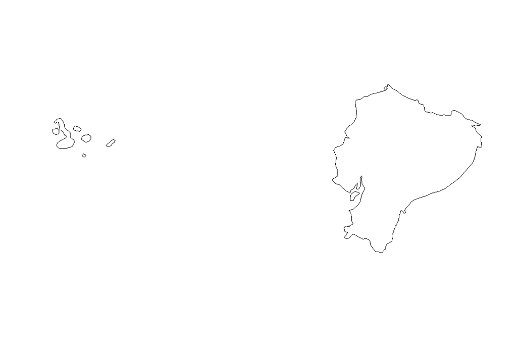

```r
plot(CNpoly_low$geometry)
```

## 2.2 High presicion maps

The low precision map above is fine for general things, but the coastline and islands are not precise enough for pour type of data. Here we shall import a more precise one

1. Import a higher definition map from `rworldxtra` package

```r
data(countriesHigh)
CNhigh = st_as_sf(countriesHigh)
```

2. Filter the country you want, creates a *NCpoly* object

```r
CNpoly <- CNhigh %>% filter(ADMIN == country)
```

## 2.3 High precision map with administration levels

In the above map, we only have the country. Below you can extract a high presicion map with admin levels. The country is defined by it three letter code, which was set above. The *getData* function from the *raster* package allows us to get all sorts of data. Here we specifiy the country and the admin level we want (1=regions)  
*country_3* variable is defined above (the three letter code of a country). This will download some files.

```r
x <- getData('GADM', country=country_3, level=1)
x_proj = spTransform(x, CRS("+proj=longlat +datum=WGS84 +no_defs +ellps=WGS84 +towgs84=0,0,0"))
```

## 2.4 Plot *country* map with `ggplot2`

Plot the high definition country filtered above.

First, we set some extra limits around the country, so that it isn’t too tight. You can change the region around the country with *dist.* Here at 0.7.  
This creates a *limsCN* object

```r
limsCN <- st_buffer(CNpoly, dist = 0.7) %>% st_bbox
```

Plot map with *ggplot2*. This package has many different options that can be changed.  
Here for the country without admin *CNpoly*

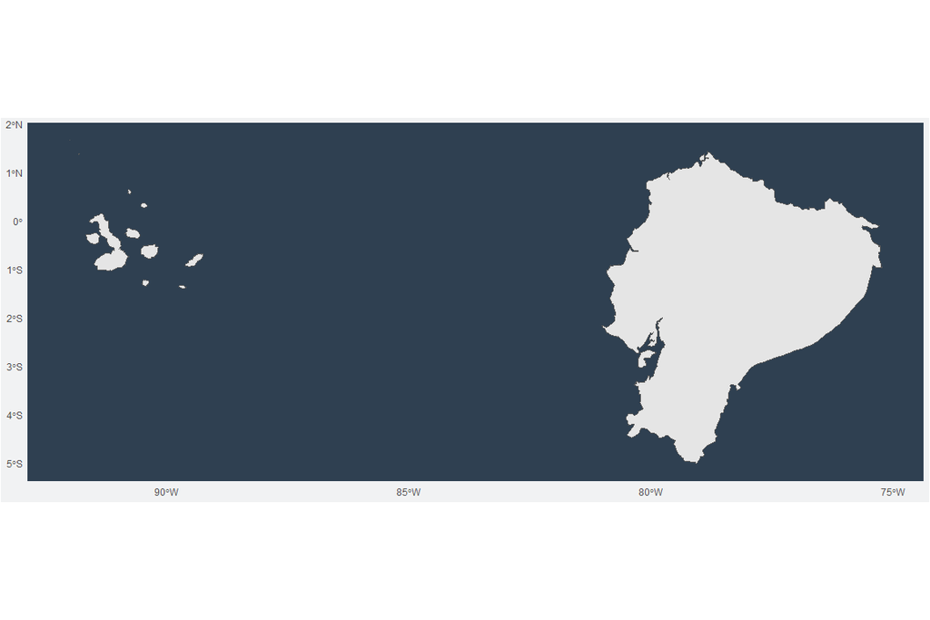

```r
divpolPlot <-
  ggplot() +
  geom_sf(data = CNpoly) +
  coord_sf(
    xlim = c(limsCN["xmin"], limsCN["xmax"]),
    ylim = c(limsCN["ymin"], limsCN["ymax"])
  ) +
  theme(
    plot.background = element_rect(fill = "#f1f2f3"),
    panel.background = element_rect(fill = "#2F4051"),
    panel.grid = element_blank(),
    line = element_blank(),
    rect = element_blank()
  )
divpolPlot
```

### 2.4.1 We can *crop* around mainland Ecuador

Ecuador also includes the Galapagos, but, as you can see above, it makes a large map. Here we are not interested in the Galapagos. We can *crop* to specific regions if we want. Here we shall crop just to show mainland Ecuador.  
You have to add the extent manually.  
**For the species/genus richness maps we shall use this cropped map.**

Here we shall just crop to Ecuador, but you could crop to just the coast for exemple.

```r
out <- st_crop(CNpoly, xmin = -81, xmax = -74, ymin = -5, ymax = 10)
```

Transform this to an *sf* object (sf is a sort of R spatial package):

```r
ne = out$geometry
st_make_valid(ne)
```

```
## Geometry set for 1 feature
## Geometry type: MULTIPOLYGON
## Dimension:     XY
## Bounding box:  xmin: -81 ymin: -5.007451 xmax: -75.22726 ymax: 1.434177
## CRS:            +proj=longlat +ellps=WGS84 +datum=WGS84 +no_defs +towgs84=0,0,0
```

```r
ne = st_as_sf(ne)
```

Redefine the limits again:

```r
limsNE <- st_buffer(ne, dist = 0.7) %>% st_bbox
```

Plot again:

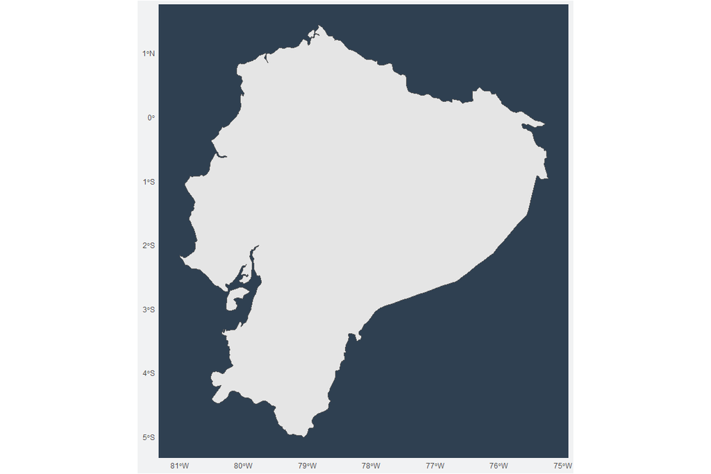

```r
divpolPlot <-
  ggplot() +
  geom_sf(data = ne) +
  coord_sf(
    xlim = c(limsNE["xmin"], limsNE["xmax"]),
    ylim = c(limsNE["ymin"], limsNE["ymax"])
  ) +
  theme(
    plot.background = element_rect(fill = "#f1f2f3"),
    panel.background = element_rect(fill = "#2F4051"),
    panel.grid = element_blank(),
    line = element_blank(),
    rect = element_blank()
  )
divpolPlot
```

## Plot *regional* map with `ggplot2`

Our dataset contains records from the Choco region. So we shall plot our records in the Choco region. Here we shall indicate a region using coordinates, rather than filtering for a country.  
We use the *CNhigh* object.  
Here coordinates for Ecuador cropped CAREFULL: *xlat* and *ylong* are defined above.

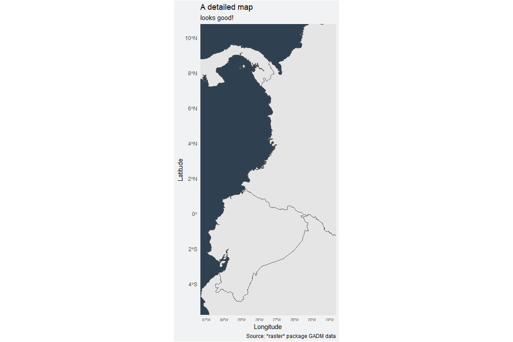

```r
divpolPlot <-
  ggplot() +
  geom_sf(data = CNhigh) +
  coord_sf(
    xlim = xlat,
    ylim = ylong
  ) +
  theme(
    plot.background = element_rect(fill = "#f1f2f3"),
    panel.background = element_rect(fill = "#2F4051"),
    panel.grid = element_blank(),
    line = element_blank(),
    rect = element_blank(),
    axis.text.x = element_text(size = 6) # you can adjust the size of the x axis here
  ) +
  labs(x='Longitude',y='Latitude',
       title="A detailed map",
       subtitle='looks good!',
       caption='Source: *raster* package GADM data')
divpolPlot
```

## 2.5 Add some climatic data to the plots

Here we shall download data from WorldClim and plot it with the map.

Download or import climatic data from *WorldClim*

If already downloaded and stored on your PC locally:

```
climate=getData('worldclim', var='bio',res=2.5, download=FALSE)
```

Otherwise (this step can take some time (ca. 123 Mb of data)):

```r
climate=getData('worldclim', var='bio',res=2.5)
```

Crop to region of interest

```r
climate <- crop(climate,extent(-81, -73,-5, 11))
```

Raster the layer you want, here *bio12*

Here we extract values for *bio12* variable, which is Annual Precipitation.  
Other variables can be chosen here if you want:  
- BIO12 = Annual Precipitation  
- BIO1 = Annual Mean Temperature  
- BIO15 = Precipitation Seasonality (Coefficient of Variation)

```r
raster <- climate$bio12
```

Clean na values. We shall get rid of non existent values (NA):

```r
rasdf <- as.data.frame(raster,xy=TRUE)%>%drop_na()
```

We can plot this climatic map:

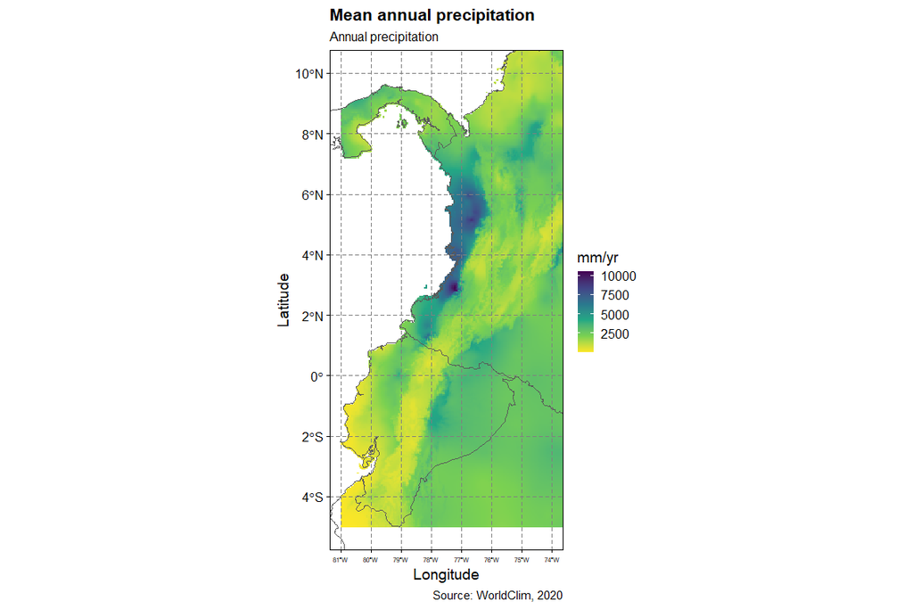

```r
ggplot()+
  geom_raster(aes(x=x,y=y,fill=bio12),data=rasdf) +
  geom_sf(fill='transparent', data = CNhigh) +
  coord_sf(
    xlim = xlat,
    ylim = ylong) +
  scale_fill_viridis_c('mm/yr',direction = -1) +
  labs(x='Longitude',y='Latitude',
       title="Mean annual precipitation",
       subtitle='Annual precipitation',
       caption='Source: WorldClim, 2020')+
  cowplot::theme_cowplot() +
  theme(panel.grid.major = element_line(color = gray(.5),
                                        linetype = 'dashed',
                                        size = 0.5),
        panel.grid.minor = element_blank(),
        panel.background = element_rect(fill=NA,color = 'black'),
        panel.ontop = TRUE,
        axis.text.x = element_text(size = 6) # you can adjust the size of the x axis here
        )
```

# 3 Plot species distribution data

## 3.1 Import original raw occurence dataset and clean

```r
df <- read.csv("data/occs_cleaned_palm_GBIF_COU_QCA_20102021.csv", header = TRUE, sep = ";", stringsAsFactors = FALSE, na.strings = c("", "NA"))
```

*df* will contain all the records, inlcusing non identified specimens that we cannot use for diversity analyses. We shall drop those here and save it as *df_id* which will be used for the diversity analyses afterwards

```r
df_id = df[!(is.na(df$genus) | is.na(df$species)), ]
```

Transform to SF object

It needs to be converted in to geosptial version with correct projection (here 4326 (WGS84)) see here: https://www.youtube.com/watch?v=2UZKm2Kc88U

```r
df_id_sf = st_as_sf(df_id, coords = c(x = "ddlong", y = "ddlat"), crs = "+proj=longlat +datum=WGS84 +ellps=WGS84 +towgs84=0,0,0")
```

The text below is automatically generate in Rmarkdown.

Our database contains **4191** unique records representing **26** genera and **102** species.

## 3.2 Plot distribution data on *regional* map **without** climatic data

Here we shall plot all records in our database, identified or not (thus using the *df* object)  
We have now added a *geom_point* argument to the ggplot script:

`geom_point(data=df, aes(x=ddlong, y=ddlat), bg = rgb(red = 1, green = 0, blue = 0, alpha = 0.5), col = "black", pch = 21, cex=2) +`

Color and shape of points can be changed in the script. In our file, the columns *ddlat* and *ddlong* indicate the coordinates.

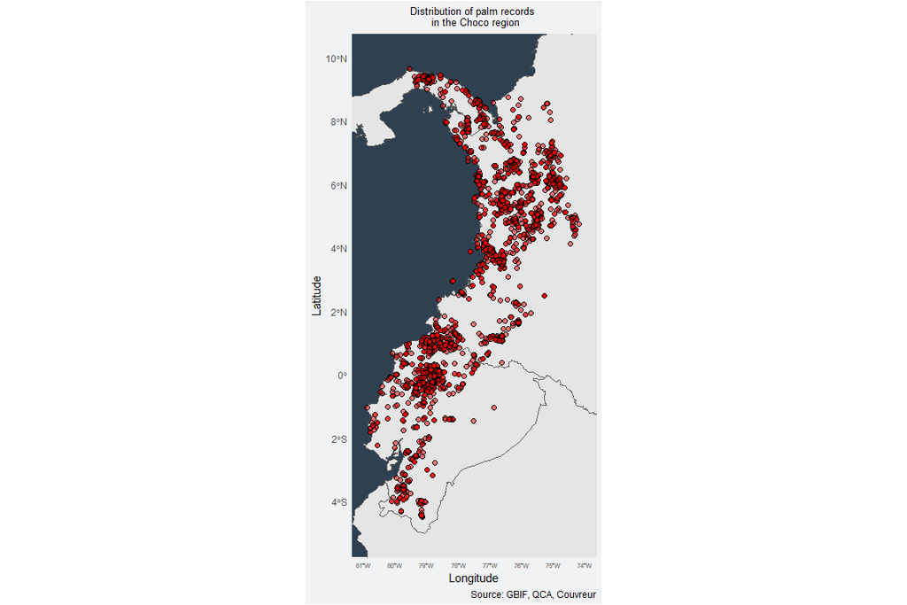

```r
divpolPlot <-
ggplot() +
  geom_sf(data = CNhigh) +
  geom_point(data=df, aes(x=ddlong, y=ddlat), bg = rgb(red = 1, green = 0, blue = 0, alpha = 0.5), col = "black", pch = 21, cex=2) +
  coord_sf(
    xlim = xlat,
    ylim = ylong
  ) +
  theme(
    plot.background = element_rect(fill = "#f1f2f3"),
    panel.background = element_rect(fill = "#2F4051"),
    panel.grid = element_blank(),
    line = element_blank(),
    rect = element_blank(),
    axis.text.x = element_text(size = 6), # you can adjust the size of the x axis here
    plot.title = element_text(size = 10, hjust = 0.5) # you can adjust the size of main title here
                 ) +
    labs(
      x='Longitude',y='Latitude',
    title="Distribution of palm records \n in the Choco region",
    caption='Source: GBIF, QCA, Couvreur'
    )

    divpolPlot
```

## 3.3 Plot distribution data on *regional* map **with** climatic data

This ggplot script is different than the one above as it adds the climate data.

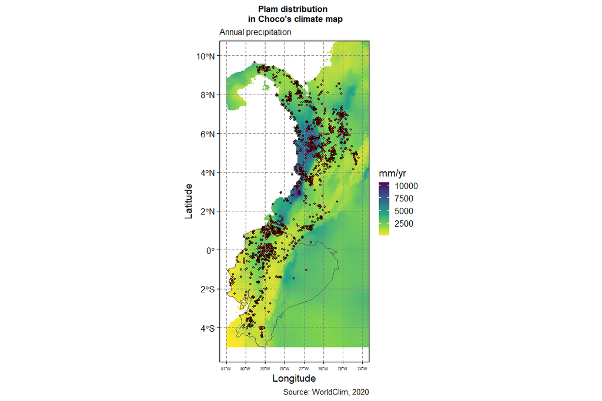

```r
ggplot()+
  geom_raster(aes(x=x,y=y,fill=bio12),data=rasdf)+
  geom_sf(fill='transparent',data=CNpoly)+
  scale_fill_viridis_c('mm/yr',direction = -1)+
  coord_sf(expand=c(0,0))+
  geom_point(data=df, aes(x=ddlong, y=ddlat), bg = rgb(red = 1, green = 0, blue = 0, alpha = 0.5), col = "black", pch = 21, cex=1) +
  coord_sf(
    xlim = xlat,
    ylim = ylong
  ) +
  labs(x='Longitude',y='Latitude',
       title="Plam distribution \n in Choco's climate map",
       subtitle='Annual precipitation',
       caption='Source: WorldClim, 2020')+
  cowplot::theme_cowplot()+
  theme(panel.grid.major = element_line(color = gray(.5),
                                        linetype = 'dashed',
                                        size = 0.5),
        panel.grid.minor = element_blank(),
        panel.background = element_rect(fill=NA,color = 'black'),
        axis.text.x = element_text(size = 6), # you can adjust the size of the x axis here
        plot.title = element_text(size = 13, hjust = 0.5), # you can adjust the size of main title here
        panel.ontop = TRUE)
```

# 4 Plot species richness

## 4.1 Prepare species distribution data

Create a new dataframe with just *species*, *ddlong* and *ddlat*:

```r
df_1 = df_id[c("genus", "species", "ddlat","ddlong")]
```

Transform to SF object

It needs to be converted in to geosptial version with correct projection (here 4326 (WGS84)) see here: https://www.youtube.com/watch?v=2UZKm2Kc88U

```r
df_sf = st_as_sf(df_1, coords = c(x = "ddlong", y = "ddlat"), crs = 4326)
```

## 4.2 Create a grid

Here we shall use the cropped Ecuador region to create the grid *ne* object created above.

```r
w = 0.25
```

Create grid around the region of interest

```r
CNGrid <- ne %>%
  st_make_grid(cellsize = w) %>%
  st_intersection(ne) %>%
  st_sf() %>%
  mutate(cellid = row_number())
```

## 4.3 Optional: Plot empty grid just to see what it looks like

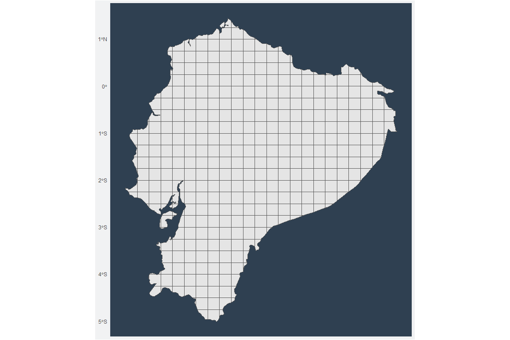

```r
gridPlot <-
  ggplot() +
  geom_sf(data = ne) +
  geom_sf(data = CNGrid) +
  coord_sf(
    xlim = c(limsNE["xmin"], limsNE["xmax"]),
    ylim = c(limsNE["ymin"], limsNE["ymax"])
  ) +
  scale_x_continuous(breaks = c(-84)) +
  theme(
    plot.background = element_rect(fill = "#f1f2f3"),
    panel.background = element_rect(fill = "#2F4051"),
    panel.grid = element_blank(),
    line = element_blank(),
    rect = element_blank()
  )
gridPlot
```

## 4.4 Plot *species* richness analysis

Here we shall count the number of species per grid

### 4.4.1 Make richness grid

Here we shall first count the number of species per grid and save that in the *richness_grid* object.  
we use *dplyr* package for this. %>% are *pipes*, that is we compile different functions one after the other.  
First we overlap the distribution data with the grid. This produces a table where we have species per cell. Then we group by cellid and species, and count number of unique species per grid (tally), then we ungroup ad group again on cell id and count number of species per cellid.

```r
richness_grid <- CNGrid %>% st_join(df_id_sf) %>%
  group_by(cellid, species) %>%
  tally() %>%
  filter(!is.na(species)) %>%
  ungroup() %>%
  mutate(overlap = ifelse(!is.na(species), 1, 0)) %>%
  group_by(cellid) %>%
  summarize(num_species = sum(overlap))
```

### 4.4.2 Plot richness

Now we can plot the grid with the species richness.  
We use the *scico* package for the graded scale bar. This can be changed to other colors if needed, see scico.  
In the script below, we indicate that grids with NA values should be transparent, so they will appear in grey.  
For the tile we create a *chart_title_sp* object so we can automatically add in the size of the grids (variable w):

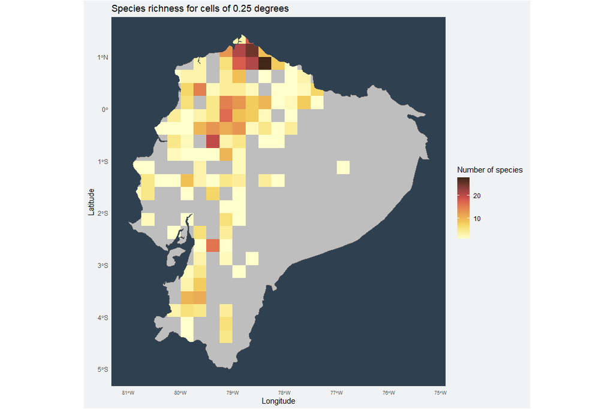

```r
chart_title_sp <- paste("Species richness for cells of",w ,"degrees")

gridRichCN <-
  ggplot(richness_grid) +
  geom_sf(data = ne, fill = "grey", size = 0.1) +
  geom_sf(aes(fill = num_species), color = NA) +
  scale_fill_scico(palette = "lajolla", end = 0.9, na.value = "transparent") +
  coord_sf(
    xlim = c(limsNE["xmin"], limsNE["xmax"]),
    ylim = c(limsNE["ymin"], limsNE["ymax"])
  ) +
    scale_x_continuous(breaks = waiver()) +
  theme(
    plot.background = element_rect(fill = "#f1f2f3"),
    panel.background = element_rect(fill = "#2F4051"),
    panel.grid = element_blank(),
    line = element_blank(),
    rect = element_blank(),
    axis.text.x = element_text(size = 7)
  ) +
  labs(x='Longitude',y='Latitude',
       title = chart_title_sp,
       fill='Number of species')
gridRichCN
```

### 4.4.3 Plot **genus** richness

Finally, we can do the same thing for the number of genera. We simply change the counting on the *genus* column in the script below:

```r
richness_grid_gen <- CNGrid %>% st_join(df_sf) %>%
        group_by(cellid, genus) %>%
        tally() %>%
        filter(!is.na(genus)) %>%
        ungroup() %>%
        mutate(overlap = ifelse(!is.na(genus), 1, 0)) %>%
        group_by(cellid) %>%
        summarize(num_gen = sum(overlap))
```

Now we can plot the genus richness: For the tile we create a *chart_title_gn* object so we can automatically add in the size of the grids (variable w):

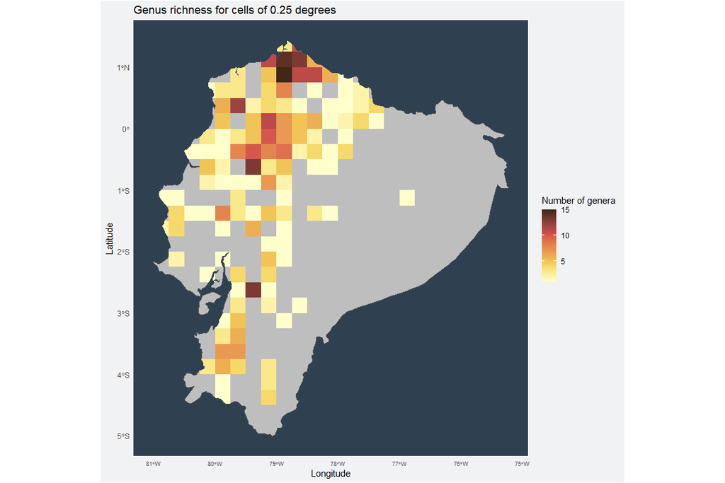

```r
chart_title_gn <- paste("Genus richness for cells of",w,"degrees")

gridRichCN_gen <-
  ggplot(richness_grid_gen) +
  geom_sf(data = CNpoly, fill = "grey", size = 0.1) +
  geom_sf(aes(fill = num_gen), color = NA) +
  scale_fill_scico(palette = "lajolla", end = 0.9, na.value = "transparent") +
  coord_sf(
    xlim = c(limsNE["xmin"], limsNE["xmax"]),
    ylim = c(limsNE["ymin"], limsNE["ymax"])
  ) +
  scale_x_continuous(breaks = waiver()) +
  theme(
    plot.background = element_rect(fill = "#f1f2f3"),
    panel.background = element_rect(fill = "#2F4051"),
    panel.grid = element_blank(),
    line = element_blank(),
    rect = element_blank(),
    axis.text.x = element_text(size = 7)
  ) +
  labs(x='Longitude',y='Latitude',
       title = chart_title_gn,
       fill='Number of genera')
gridRichCN_gen
```